# Minimum Indonesia Model with Boxcars

Ernesto

December 13, 2017

## Boxcar re-run

The way we designed POSEIDON is that each module is plug and play. Here I take the [first minimum Indonesian model](http://carrknight.github.io/poseidon/minimum_indonesia.html) but plug in the fixed boxcar biological model we calibrated [here](http://carrknight.github.io/poseidon/selex.html).

We use the Aphareus rutilans parameters and selectivity curve calibrated in the non-spatial model:

| Measure | Value |
| --- | --- |
| Min Length | 10cm |
| Max Length | 113cm |
| Number of bins | 100 |
| Yearly K | 0.364 |
| Allometric $\alpha$ | 0.015 |
| Allometric $\beta$ | 2.961 |
| Yearly Mortality Rate | 0.1 |
| ———————– | ———– |
| Catchability | 0.000029 |
| Selectivity intercept | 67.486064 |
| Selectivity slope | 7.258574 |

This is plugged back into our Indonesia map (very coarse, each square 20 km wide).

The starting population has 10M fish, all at bin 0 (10 cm long). Each year another 1M spawn. Fish spawn in one of four cells (the “nursery” cells) and don’t move until they are 40cm or longer. They are depth constraints between 800 and 1500m.

With no fishing, they spread over time like this:

[video not shown]

We would like to incentivise fishers to catch more fish above maturity, that is when it’s longer than 66cm. Fishers can’t change gear or fish selectively but if they fish away from nursery areas they ought to be able to limit non-mature catches.

First, we can try to fine landings that are smaller than 66cm. Originally both mature and non-mature fish sells for 10$ per kg landed. Given the initial biomass, the selex curve (which we didn’t recalibrate) and the fishing behaviour with no fines about 7.5% of all landings (by weight) are immature. If we increase fines we can get that percentage down to about 3%.

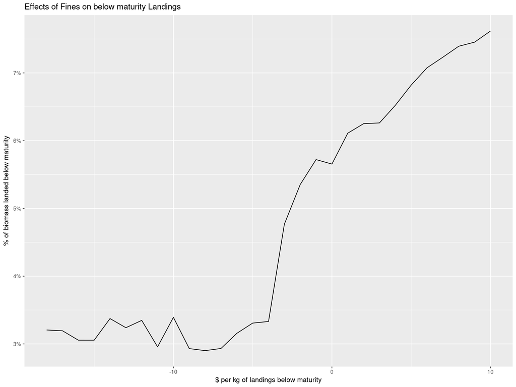

And we can also look at what happens to the selection curve as we impose a fine. As you can see the landings shift to the right (higher red bars in higher length bins, lower red bars in lower length bins). The gear selection curve hasn’t budged but effectively the selection curve (due to changes in location fished) has moved to the right.

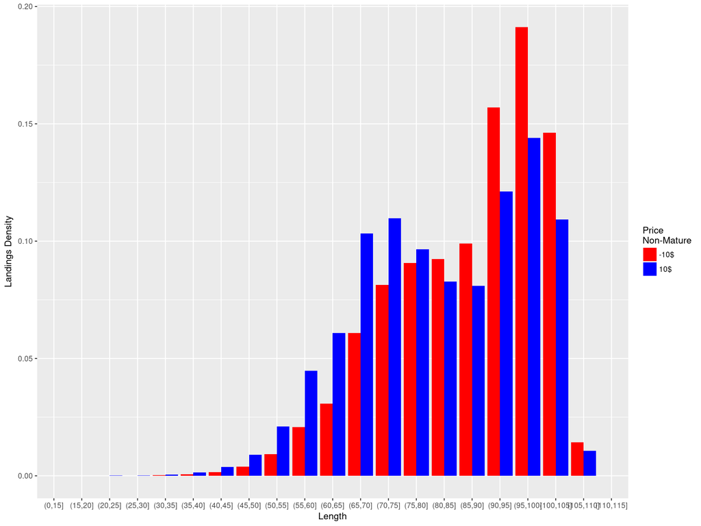

We can do the same exercise with subsidies. Same result: curve shifts to the right.

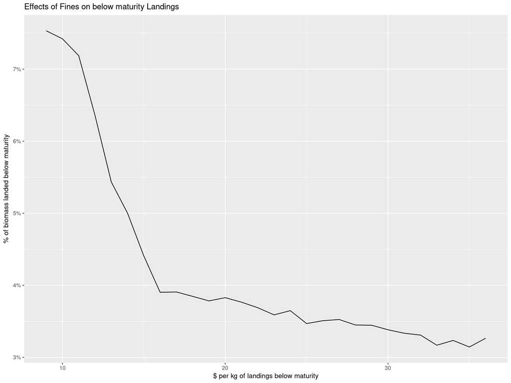

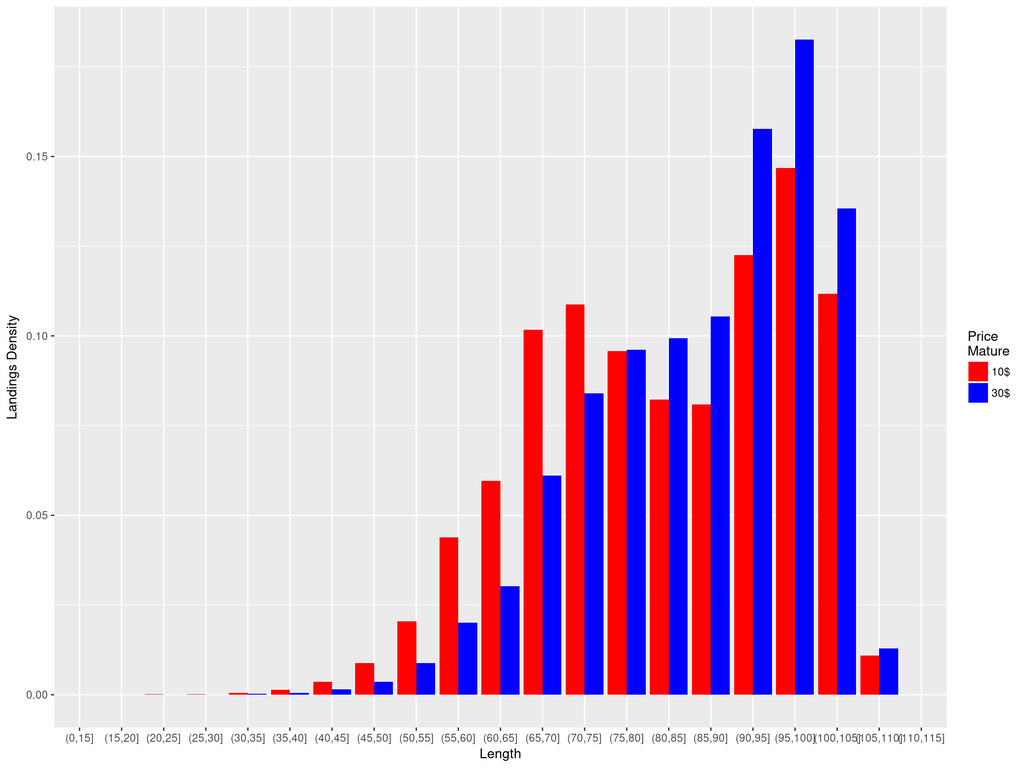